# SDS Day 2

steppe

2/6/2022

Assigned Reading: Chapter 3 of Spatial Data Science

# Topology

- Many/Most geographic operations are geometric in nature

## Theoretical Relations

- Dimensionally Extended 9-Intersection Model (DE-9IM)
- Developed to query spatial databases
- Serves as the standard for describing relations

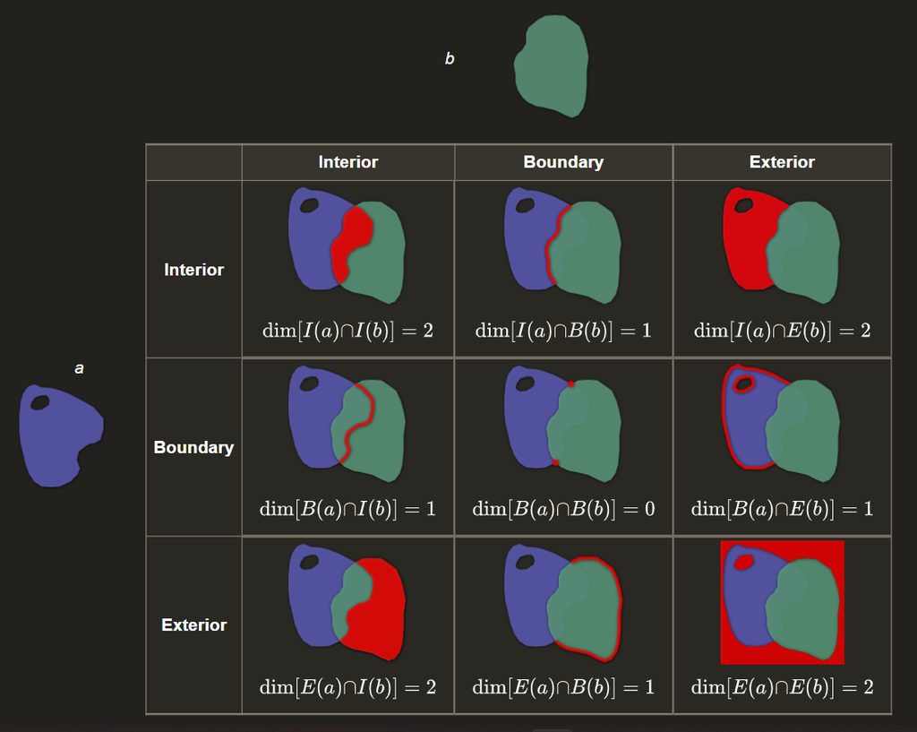

DE-9IM, By Krauss

In the example in the Upper Middle panel

The dimensions which contain the intersection of the ‘Interior’ of ‘A’ to the ‘Boundary’ of ‘B’ is equal to a line.

$$dim[I(a)∩B(b)] = 1$$

- where ‘I’ is the ‘Interior’ (of ‘a’) & ‘B’ is the ‘Boundary’ (of ‘b’)

$$\text{∩ is the 'Intersection'}$$

- ‘1’ denotes that the product of the intersection is a line

In the example in the Upper Middle panel

The dimensions which contain the intersection of the ‘Interior’ of ‘A’ to the ‘Boundary’ of ‘B’ is equal to a line.

## Applications

When identifying solutions to a problem we are generally interested in how features affect each other. This schema provides us a framework for organizing our area of analyses, and subsetting the appropriate data.

We are generally interested in :

- *dim[I(a)∩I(b)] = 2* Which values are in both polygons
- *dim[I(a)∩B(b)] = 1* Which values are in ‘a’, and at the boundary of ‘b’
- *dim[I(a)∩E(b)] = 2* Which values are in ‘a’, but not in ‘b’
- *dim[B(a)∩I(b)] = 1* Which values are at the boundary of ‘a’, and in ‘b’
- *dim[B(a)∩B(b)] = 0* Which values are at the shared boundaries of ‘a’ and ‘b’
- *dim[B(a)∩E(b)] = 1* Which values are at the boundary of ‘a’, and outside ‘b’
- *dim[E(a)∩I(b)] = 2* Which values are in ‘b’ but not in ‘a’
- *dim[E(a)∩B(b)] = 1* Which values are at the boundary of ‘b’ and outside ‘a’
- *dim[E(a)∩E(b)] = 2* Which values are outside both ‘a’ and ‘b’

# Geometric Operations on Spatial Predicates

## Theoretical Properties

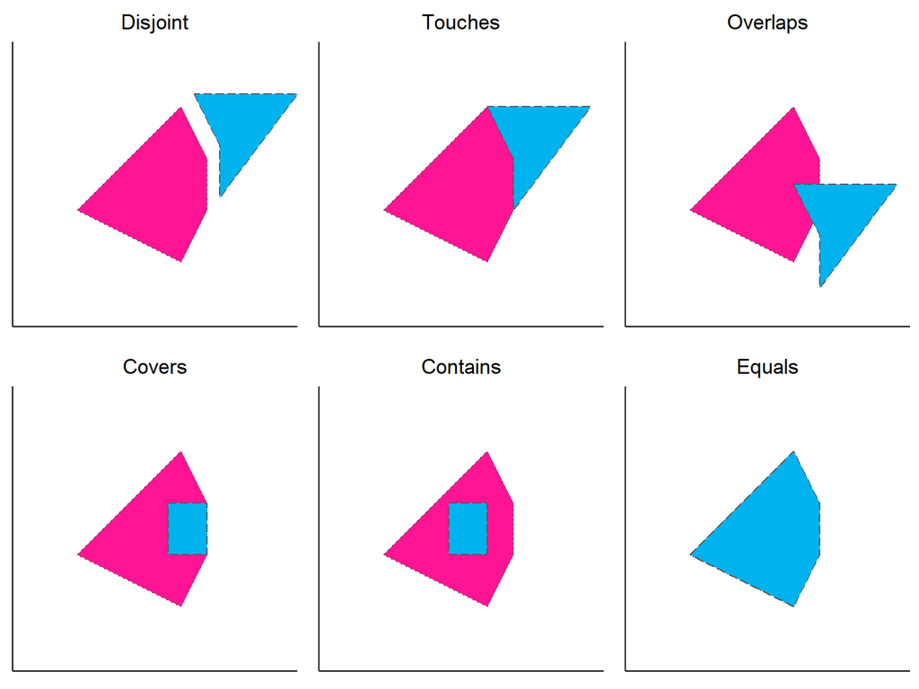

Spatial Predicates after Egenhofer and Herring (1990)

- **Disjoint** Neither ‘A’ nor ‘B’ touch at any position
- **Touches** The boundaries of ‘A’ and ‘B’ touch
- **Covers** Feature ‘A’ is encapsulated by ‘B’ on many sides, at least a boundary of ‘A’ shares at least a partial border with a border of ‘B’
- **Contains** All borders of one feature are contained by another
- **Overlap** Portions of the interior of feature ‘A’ overlap the interior of ‘B’
- **Equals** ‘A’ and ‘B’ have identical extents.
- postGIS implements the following three (additional) tests:
  - **Intersects** (includes: ‘st_contains’, ‘st_overlaps’, ‘st_covers’)
  - **Within** (includes: ‘st_contains’)
  - **CoveredBy** (includes: ‘st_equals’)

## Applications

- Relationships can be tested using the sf package

```
st_disjoint(A, B_disjoint, sparse = F): TRUE
```

```
st_touches(A, B_touches, sparse = F): TRUE
```

[output not shown]

```
st_covers(A, B_covers, sparse = F): TRUE
```

```
st_contains(A, B_contains, sparse = F): TRUE
```

```
st_equals(A, B_equals, sparse = F): TRUE
```

```
st_equals(A, B_disjoint, sparse = F): FALSE
```

- postGIS implementation

```
st_intersects(A, B_equals, sparse = F): TRUE
```

```
st_intersects(A, B_overlap, sparse = F): TRUE
```

```
st_intersects(A, B_covers, sparse = F): TRUE
```

```
st_within(A, B_contains, sparse = F): FALSE
```

```
st_coveredby(A, B_equals, sparse = F): TRUE
```

## Spatial Join

- Combine two spatial objects, based on their spatial relations.
- May use nearly all of the predicates above, and more!
- Allows left or inner join (only records present in both objects)

```r
nghbrhd_parks <- st_join(chi_neighb, chi_parks,
               join = st_intersects,
               left = TRUE
               ) %>%
  count(pri_neigh)
```

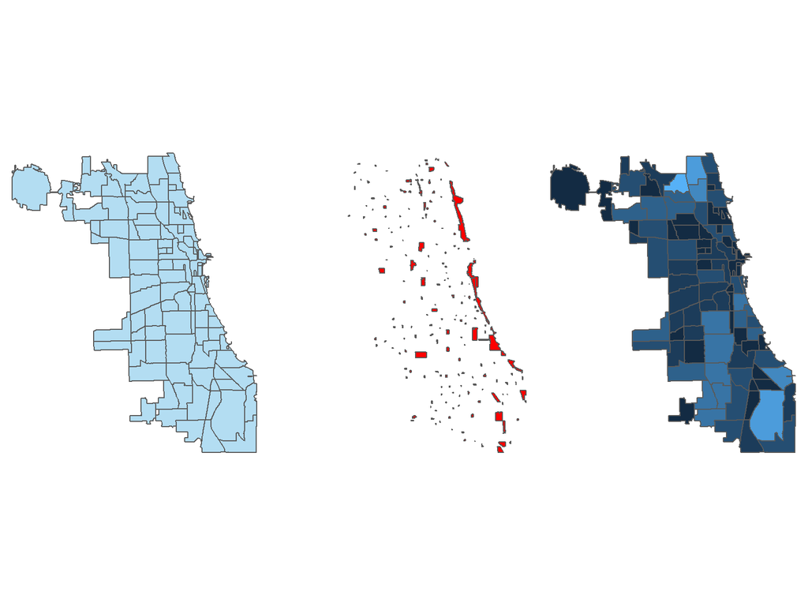

# Assorted Spatial Vector Operations

This is really a grab bag of what I and others seem to use most the often. We are going to focus on vector data.

# Aggregate Simple Features via ‘group_by’ & ‘summarize’

- Simple dplyr operations be used to combine the geometries of features

```r
regions <- us_states %>%
  group_by(REGION) %>%
  summarize(geometry = st_union(geometry))
```

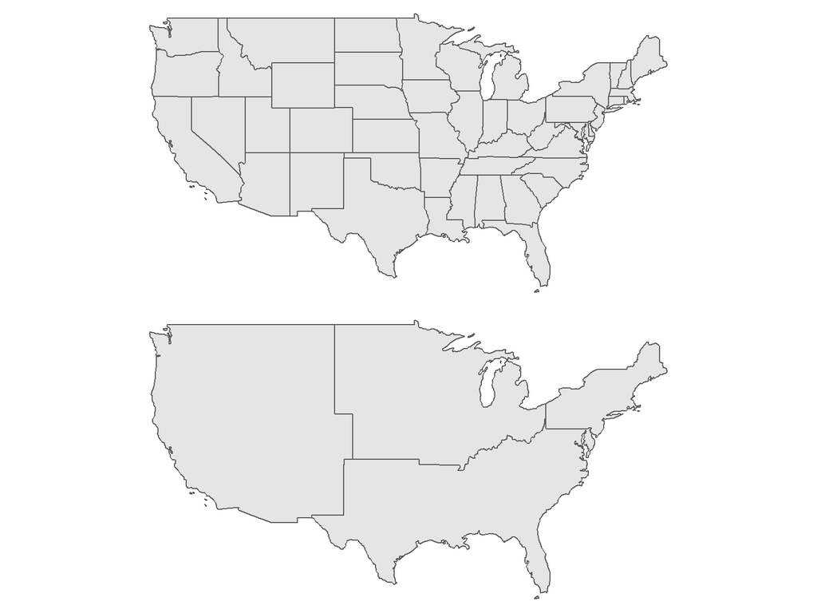

# Import a Vector file

- Many formats of vector files may be imported to R.

```r
files <- paste0('spatial_lecture_data/Chicago_Neighborhoods/' ,
                list.files('spatial_lecture_data/Chicago_Neighborhoods', ".shp"))
chi_neighb <- read_sf(files)
rm(files)
```

## Make a geometry valid as a Simple Feature

- Some data may not be in a simple format
- sf package can *generally* fix this

```r
p1 = st_as_sfc("POLYGON((0 0, 0 10, 10 0, 10 10, 0 0))")
# create a geometry which will not be valid
```

```r
st_is_valid(p1)
st_is_valid(p1, reason = TRUE)
```

```
st_is_valid(p1): FALSE
```

```
st_is_valid(p1, reason = TRUE): Self-intersection[5 5]
```

- we can make the geometry simple with st_make_valid()

```r
p2 <- st_make_valid(p1)
```

- Polygon became a multipolygon with two polygons

```
If we call class(p1), we can see that our original simple feature collection (sfc) contained: sfc_POLYGON
```

```
If we call class(p2), we can see that our valid simple feature collection (sfc) contains: sfc_MULTIPOLYGON
```

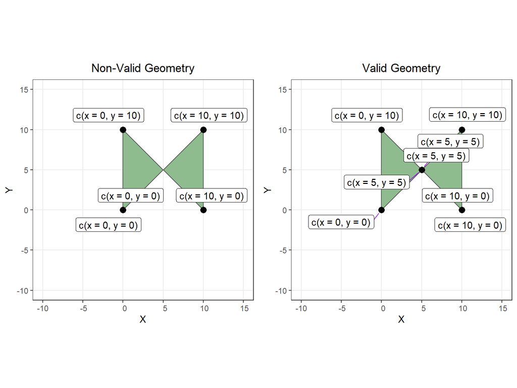

# Area Calculations

- Determine the interior area of a polygon.

```r
st_area(chi_neighb)
```

```
Units: [m^2]
[1]  4498293.6   200563.5  3016684.2   972375.8 11596322.7
```

These data are always returned in units of meters, regardless of the coordinate system specifications. However, different Coordinate Systems will give different results

```
[1] 2
```

```
integer(0)
```

```
81852.82 [m^2]
```

```
42261063 [m^2]
```

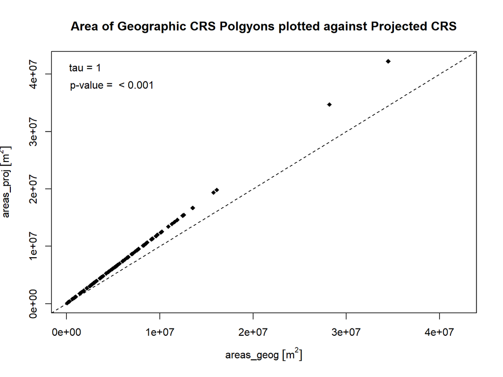

```
integer(0)
```

When we use the ‘which’ logical test, we see that all areas in the results from both sets of area calculations are different. When we plot the values we see that both sets have nearly perfect correlation.

But neither of these values are as accurate as they could be. We want to use an Equal Area projected coordinate system instead.

Here we use the NAD83 Conus Albers, a favorite of the United States Geological Survey (USGS).

```r
equal_areas_proj <- chi_neighb%>%
  st_transform(5070) %>%
# We want to use an equal area projection!
  st_area()

equal_areas_proj <- sort(equal_areas_proj)
```

While metric values are easy to convert by ‘hand’, we can also convert them using the ‘units’ package.

```r
units(equal_areas_proj) <- units::make_units(km^2)
head(equal_areas_proj)
```

```
Units: [km^2]
[1] 0.08197556 0.15334606 0.20086315 0.25781886 0.31268310 0.32418247
```

Size of the Largest and Smallest Neighborhoods in Chicago

| Smallest Neighborhood | Smallest Area (m^2) | Largest Neighborhood | Largest Area (m^2) |
| --- | --- | --- | --- |
| Magnificent Mile | 81975.56 | O’Hare | 34545390 |
| Greektown | 153346.06 | South Deering | 28222390 |
| Printers Row | 200863.15 | Englewood | 16127577 |
| Millenium Park | 257818.86 | Austin | 15796991 |
| Boystown | 312683.10 | Hegewisch | 13559961 |

## Length calculations

- Calculate the length of a linestring

```r
st_length(NU_campuses)
```

```
18578.52 [m]
```

## Boundary calculations

- ‘convert’ the exterior of a polygon to a linestring (more on this later…)
- apply st_length
- Edzar makes you do spatial problem solving **quite often**

```r
rogers_park <- chi_neighb %>%
  filter(pri_neigh == 'Rogers Park')

rogers_park <- st_cast(rogers_park, to = 'MULTILINESTRING')
rogers_park <- st_cast(rogers_park, to = 'LINESTRING')
```

```r
st_length(rogers_park)
```

```
10370.89 [m]
```

# Centroids & Point on Surface

- Centroid the “geometric center of mass of a geometry” of an object.
- If you just need an arbitrary point on the surface of an object Point on Surface will suffice.

```r
chi_cent <- st_centroid(chi_neighb)
chi_pos <- st_point_on_surface(chi_neighb)
```

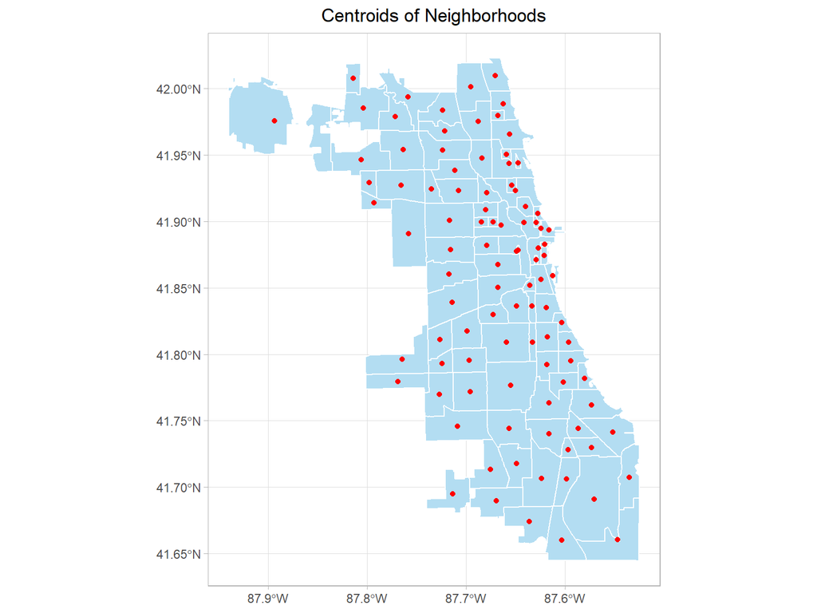

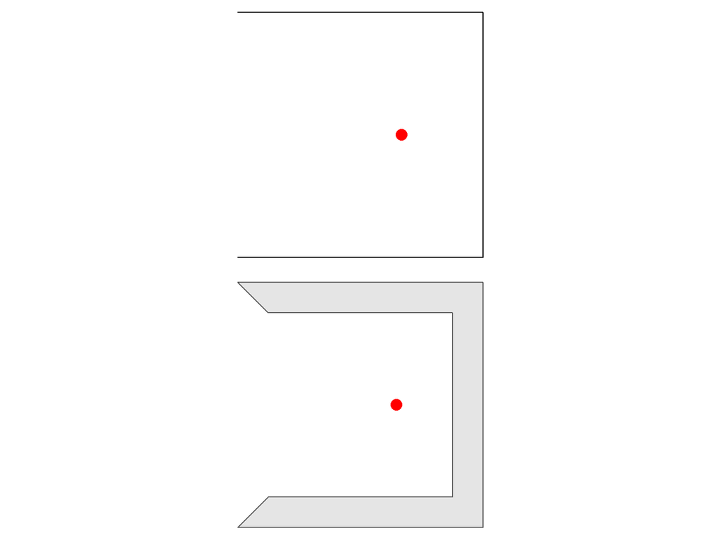

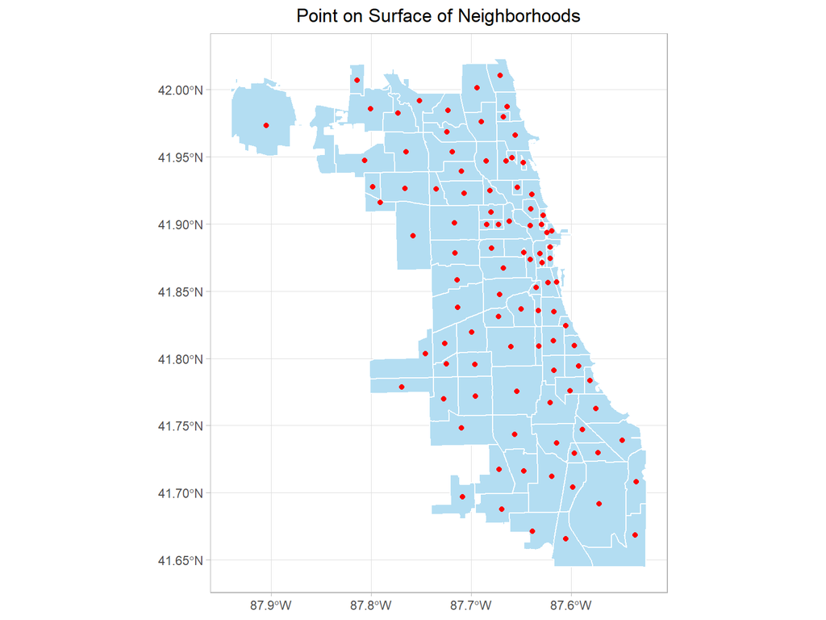

# Combine & Union Features

- *Combine* will form a multipolygon
  - Retain all geometries as a multipolygon collection
  - Lose the attributes of each feature
- *Union* will form a multipolygon
  - Retain only outer boundary geometries of features
  - Lose the attributes of each feature

```r
chi_combine <- st_combine(chi_neighb)
chi_union <- st_union(chi_neighb)
```

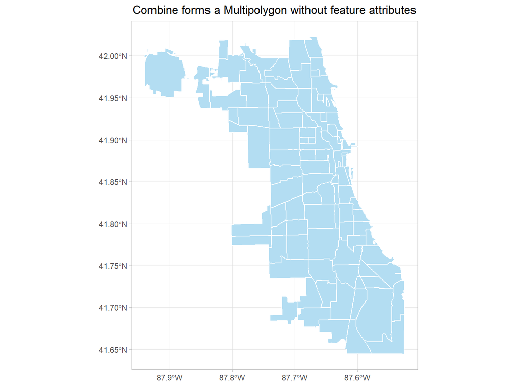

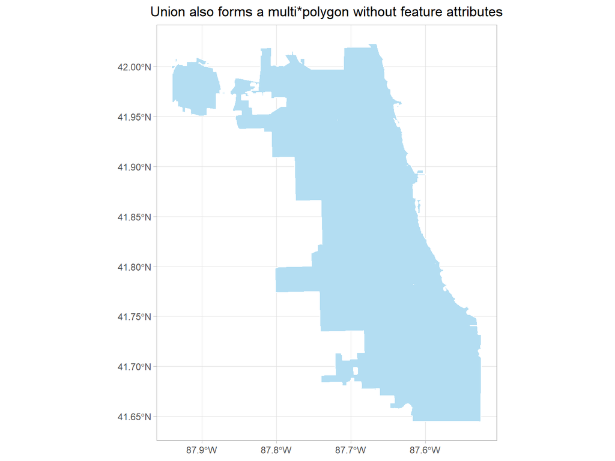

## Cast

- Can be used to extract types of geometries from a multi(polygon, line, point)geometry, or geometry collection.

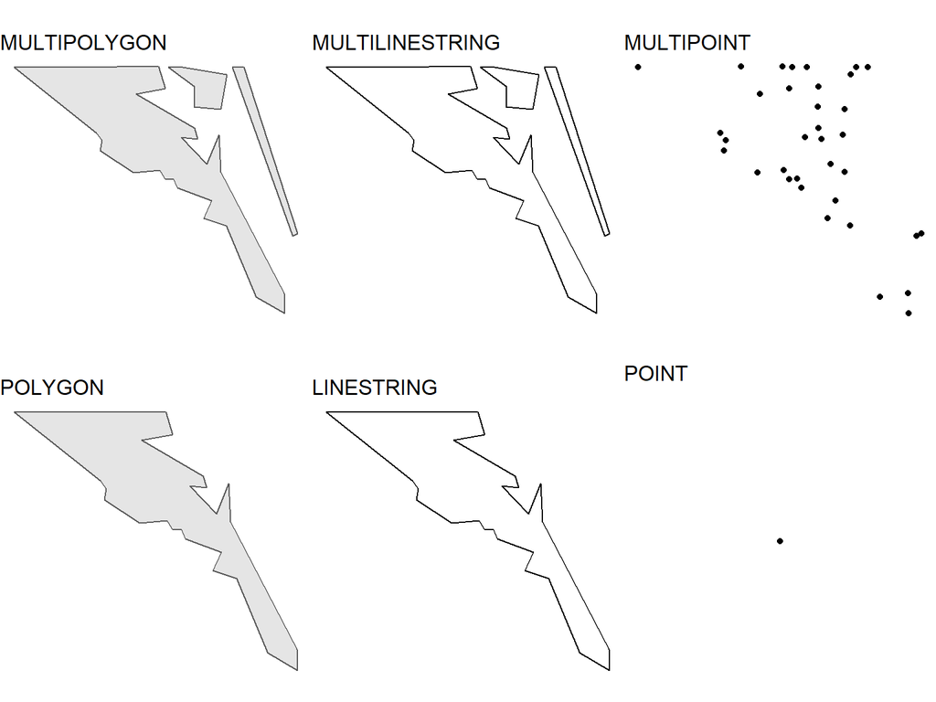

- Divide a Multipolygon into individual polygons.

```r
chi_sub <- chi_neighb[sample(size = 30, 1:nrow(chi_neighb)),]
chi_union <- st_union(chi_sub)
chi_cast <- st_cast(chi_union, to = "POLYGON")
```

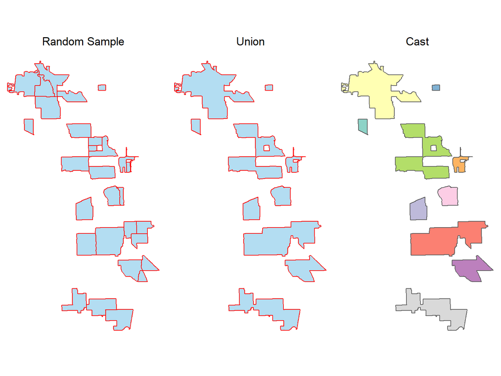

# Buffers & Convex Hulls

- Buffer: Enlarge a feature by a specified distance in X & Y dimensions
- Convex Hull: Encapsulate a feature in X & Y dimensions.

```r
chi_buffer_5k <- st_buffer(chi_union, dist = 3000)

chi_ch_by_neigh <- st_convex_hull(chi_neighb)
chi_ch_cit <- st_convex_hull(chi_union)
chi_ch_buf <- st_convex_hull(st_buffer(chi_union, dist = 3000))
```

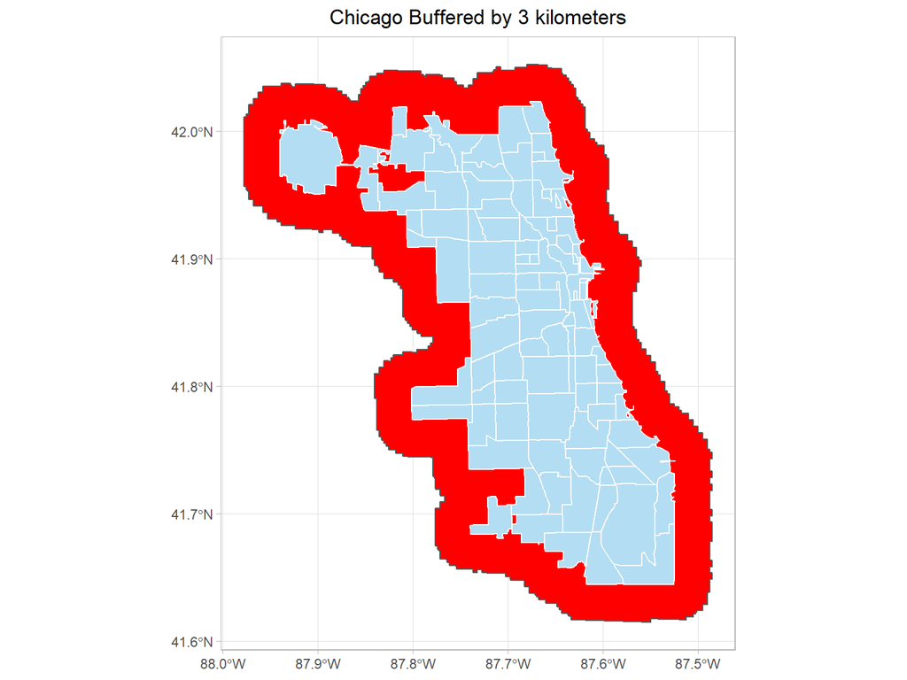

Buffer

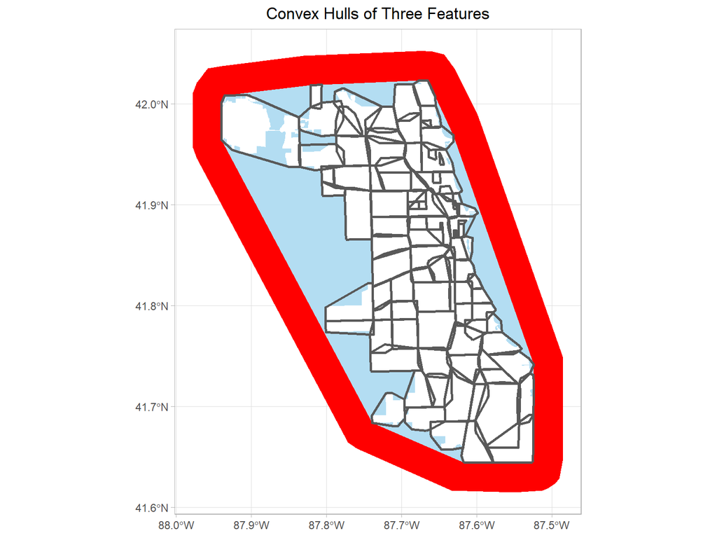

Convex Hull of Chicago Neighborhoods, The City, and a buffer of 3km

# Measuring Distances

Theory: Remember the earth is a ellipsoid, distances must be calculated along the earths curved surface

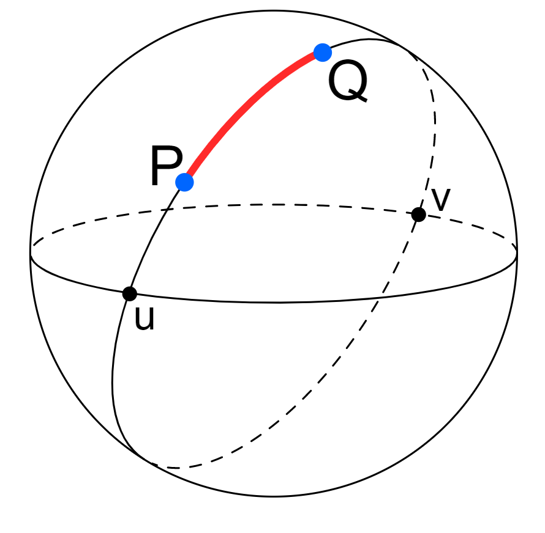

Great Circle Distance, by: ChecCheDaWaff

- *P* Point of origin
- *Q* destination
- *u* & *v* : antipodal points, positions across the ellipsoid from each other

```r
AM_FM <- st_distance(AM, FM)
AM_SM <- st_distance(AM, SM)
FM_SM <- st_distance(FM, SM)
```

| Distance (Km) | Journey |
| --- | --- |
| 1144.3 | American to Field |
| 334.7 | American to Smithsonian |
| 955.4 | Field to Smithonian |

We can visualize this with some help from Charlie Joey Hadley whom some sf compliant great circle distance code

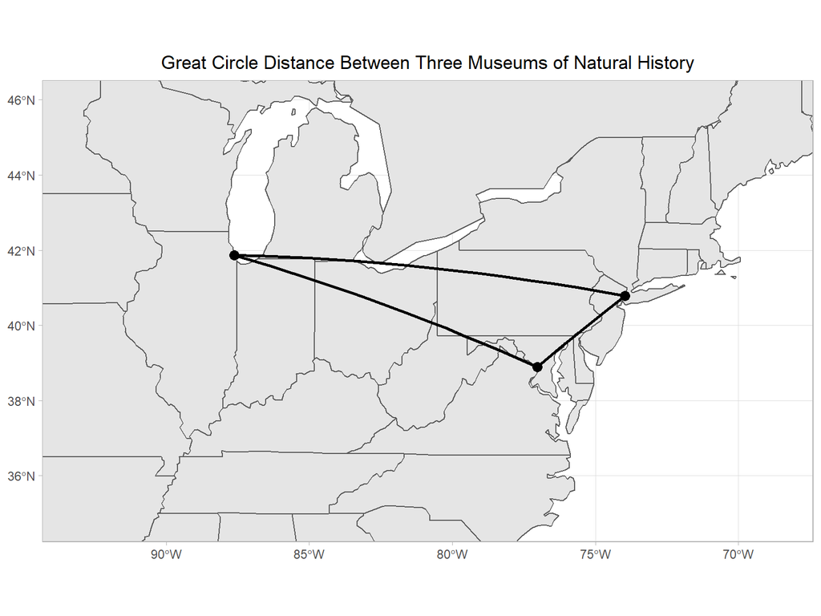

```r
gcr_distance <- st_length(great_circle_routes)
```

```r
neighborhood_centroid_dist <- st_distance(st_centroid(chi_neighb))
```

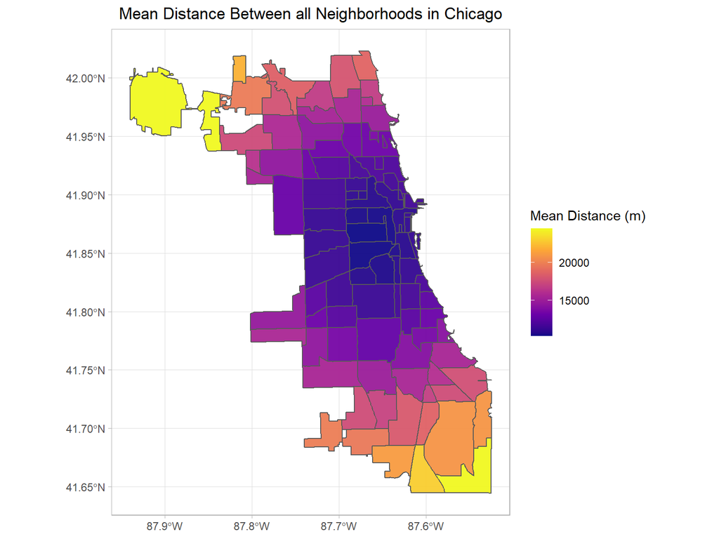

The five most Central Chicago Neighborhoods

| Neighborhood | Distance |
| --- | --- |
| Little Italy, UIC | 10291.97 |
| Lower West Side | 10350.90 |
| West Loop | 10426.27 |
| Greektown | 10455.72 |
| United Center | 10498.78 |

# An introduction to some types of Spatial Analyses

## Identifying Distance Based Neighbors

- One can find neighboring objects via distance thresholds using the spdep package
- these neighbors can be used in many types of linear regression for spatial analyses

```
Neighbour list object:
Number of regions: 81
Number of nonzero links: 1780
Percentage nonzero weights: 27.13001
Average number of links: 21.97531
2 regions with no links:
13 43
Link number distribution:

 0  4  5  6  7  8  9 15 17 18 20 21 22 23 24 25 26 27 28 29 30 32 33 34
 2  1  1  1  4  3  2  2  2  1  5  3  1  2  9 10  8  9  2  3  3  1  4  2
1 least connected region:
81 with 4 links
2 most connected regions:
26 27 with 34 links
```

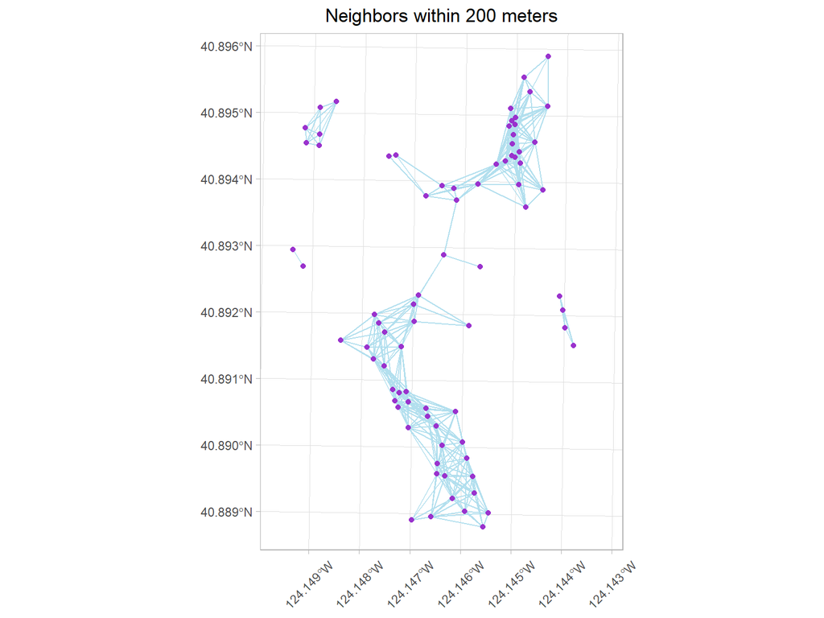

## Kernel Density Estimation of a Point Pattern

- estimate the *intensity* in a sense, the density of a process in space
- more widely used for building models than simply estimating densities via projections

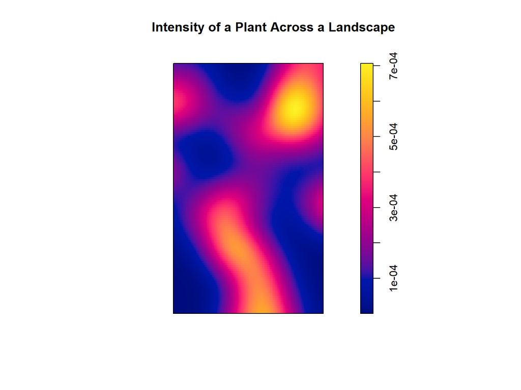

## Cluster a Point Pattern

- **D**ensity-**B**ased **S**patial **C**lustering of **A**pplications with **N**oise (DBSCAN).
- Classification algorithm for grouping objects in space
- Developed in the mid 90’s, still used and highly cited!
- Requires two terms
  - minium points: the number of points required to form a cluster
  - eps: loosely related to distance for which neighbor searches can occur
- Ripley’s K
  - Determine whether a point process is not randomly distributed
  - Points can be fit with models of distributions
  - segments of a models fit above the poisson curve have clustered distributions
  - a process which can be worth modeling.

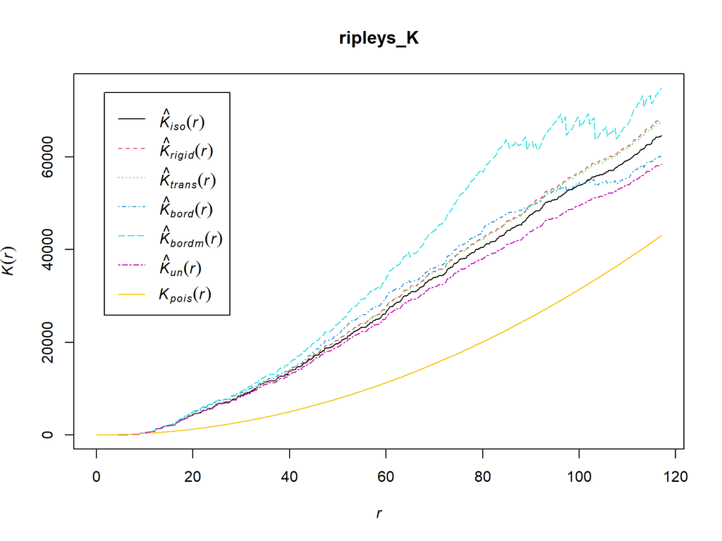

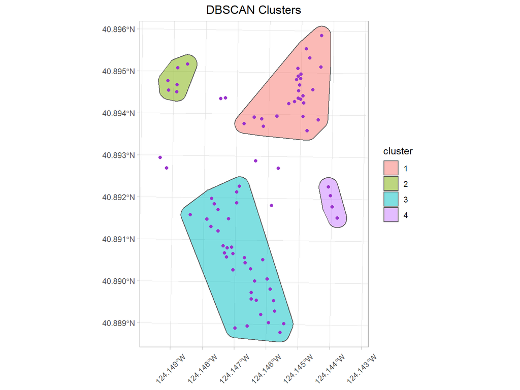

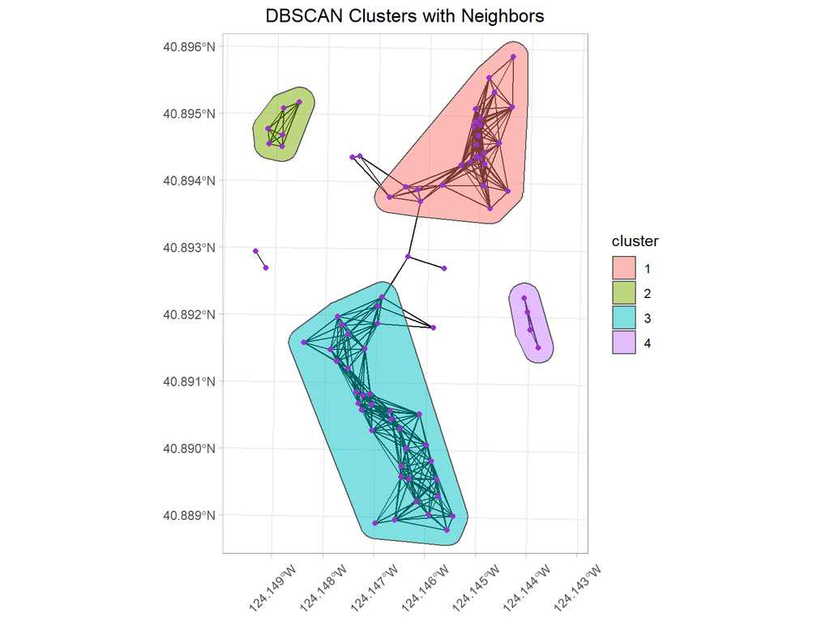

# Wrapping up the Spatial Data Science Module:

**Future Bonus SDS Office Hours** Wednesday Night at 5:00 - 6:00 in F-413.

**Notes on this Lab** My lecture notes are in the R script I used to generate all of the novel figures for this presentation. This script is much longer and more complex than Lecture 1’s script. Likewise this presentation is an .HTML file and can be launched from your computer (it was rendered directly from R using the script).

# Works Cited

https://cran.r-project.org/web/packages/gstat/vignettes/gstat.pdf Accessed 1.21.2021

Bivand, R. https://cran.r-project.org/web/packages/spdep/vignettes/nb_sf.html Accessed 1.17.2021

Clementini, Eliseo; Di Felice, Paolino; van Oosterom, Peter (1993). “A small set of formal topological relationships suitable for end-user interaction”. In Abel, David; Ooi, Beng Chin (eds.). Advances in Spatial Databases: Third International Symposium, SSD ’93 Singapore, June 23–25, 1993 Proceedings. Lecture Notes in Computer Science. 692/1993. Springer. pp. 277–295. doi:10.1007/3-540-56869-7_16. ISBN 978-3-540-56869-8. Accessed 1.16.2021

Egenhofer, M.J.; Herring, J.R. (1990). “A Mathematical Framework for the Definition of Topological Relationships”

Ester, Martin; Kriegel, Hans-Peter; Sander, Jörg; Xu, Xiaowei (1996). Simoudis, Evangelos; Han, Jiawei; Fayyad, Usama M. (eds.). A density-based algorithm for discovering clusters in large spatial databases with noise. Proceedings of the Second International Conference on Knowledge Discovery and Data Mining (KDD-96). AAAI Press. pp. 226–231. CiteSeerX 10.1.1.121.9220. ISBN 1-57735-004-9.

Hadley, C.J. https://www.findingyourway.io/blog/2018/02/28/2018-02-28_great-circles-with-sf-and-leaflet/ Accessed 1.16.2021

Gimond, M. https://mgimond.github.io/Spatial/point-pattern-analysis-in-r.html Accessed 1.22.2022

Moreno, M., Basille, M. https://r-spatial.org/r/2018/10/25/ggplot2-sf-2.html Accessed 1.22.2022

Dennett, A. https://rstudio-pubs-static.s3.amazonaws.com/126356_ef7961b3ac164cd080982bc743b9777e.html Accessed 1.21.2022